# Project 4: "Weather Forecast Post-Processing": Group Project Exercise Sheet

Group 8: Deepak Reddy Chinthaparthy, Khuzaima Aziz, Ali Bagheri ,Muhammad Abdul Wasay Khalid

Gradient Boosting Setup 2 and this is the model by which we submitted our predictions

```r
fcs.test <- readRDS("ESSD_benchmark_test_data_forecasts.rds")
fcs.train <- readRDS("ESSD_benchmark_training_data_forecasts.rds")
obs.train <- readRDS("ESSD_benchmark_training_data_observations.rds")
obs.test <- readRDS("ESSD_benchmark_test_data_observations_4students.rds")
```

***Set up 2 - Here, we conducted feature selection through cross-validation using GBM as the model and selected the most important features (i.e., top 5). We then tuned parameters for each station, which differed from setup 1 where all hyperparameters were the same except for the number of trees. This setup took considerably more time compared to the first setup, but the results were astonishingly similar. Nevertheless, we submitted the predictions of this model even though we obtained the almost same results with setup one because we performed extensive feature selection and hyperparameter tuning on each station, expecting it to perform well on untested data***

# Example of one station id 460 Hyperparameters tuning and feature selection

We fixed bag fraction as 0.7 , used parameteric grid search for other parameters ,

# **Typical Grid Parameter Search Used in Our Model**

**Uses this range of values depicted in bracket and finding out the optimal parameter:**

- **n.trees** = 300 (**100, 200, 300**)
- **interaction.depth** = 4 (**3, 4, 5**)
- **shrinkage** = 0.1 (**0.01, 0.1**)
- **minobsinnode** = 10 (**5, 10**)

# Relative Importance of Variables

The following table shows the relative importance of different variables:

[output not shown]

Features selected are "mx2t6" "mn2t6" "dmo" "p10fg6" "slhf6" out of 14 parameters.

```
Forecast at Station: 460 (1 from 49)
Elapsed time for grid search: 2.517651
Best parameters found:
$n.trees
[1] 300

$interaction.depth
[1] 4

$shrinkage
[1] 0.1

$bag.fraction
[1] 0.7

$n.minobsinnode
[1] 10

Best cross-validation error: 5.491139
[1] "mx2t6"  "mn2t6"  "dmo"    "p10fg6" "slhf6"
```

```
Using 300 trees...
```

```
[1] "Relative Performance (GBM Model) for Station 460 : 0.404987685402078"
[1] "MSE (GBM Model) for Station 460 : 3.35489153376591"
[1] "MSE (DMO) for Station 460 : 5.63835647003872"
Forecast at Station: 662 (2 from 49)
Elapsed time for grid search: 2.533227
Best parameters found:
$n.trees
[1] 300

$interaction.depth
[1] 5

$shrinkage
[1] 0.1

$bag.fraction
[1] 0.7

$n.minobsinnode
[1] 10

Best cross-validation error: 6.021765
[1] "mx2t6" "mn2t6" "dmo"   "str6"  "sshf6"
```

```
Using 300 trees...
```

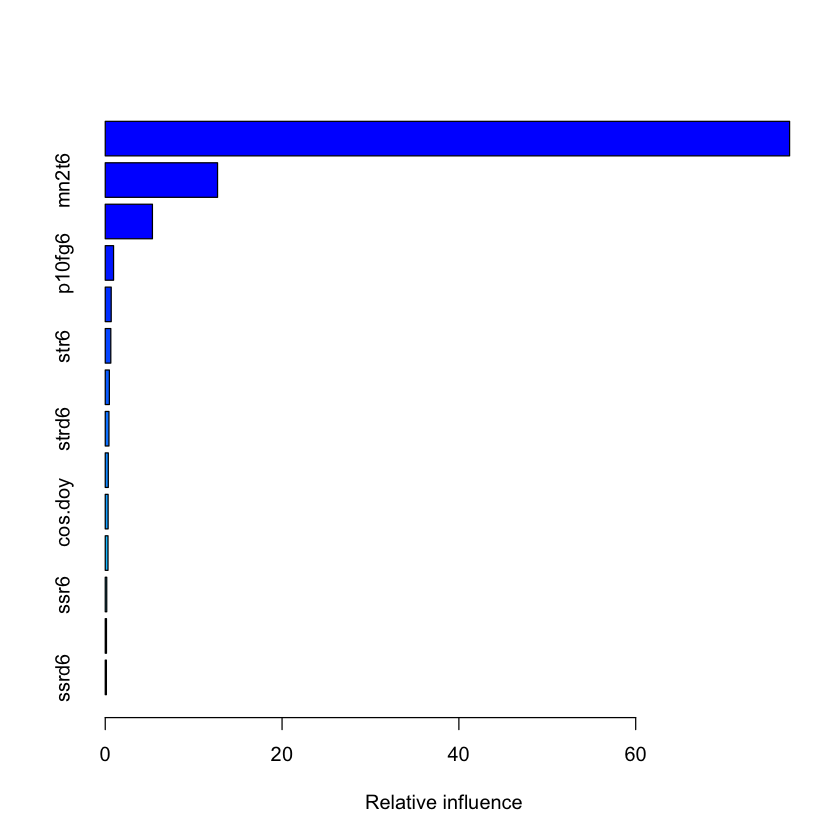

```
[1] "Relative Performance (GBM Model) for Station 662 : 0.188064690347729"
[1] "MSE (GBM Model) for Station 662 : 4.29898904872171"
[1] "MSE (DMO) for Station 662 : 5.29474330973837"
Forecast at Station: 691 (3 from 49)
Elapsed time for grid search: 2.587448
Best parameters found:
$n.trees
[1] 300

$interaction.depth
[1] 3

$shrinkage
[1] 0.1

$bag.fraction
[1] 0.7

$n.minobsinnode
[1] 10

Best cross-validation error: 6.676823
[1] "mx2t6" "mn2t6" "dmo"   "str6"  "strd6"
```

```
Using 300 trees...
```

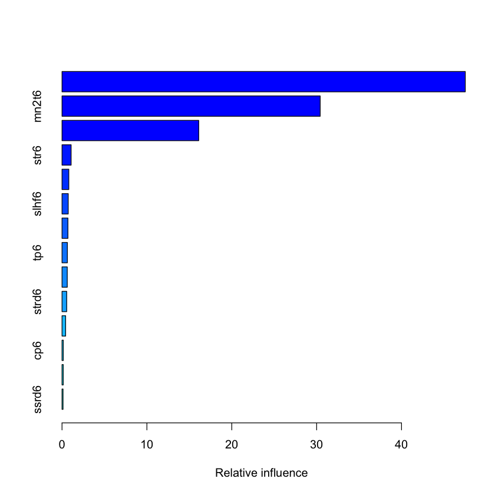

```
[1] "Relative Performance (GBM Model) for Station 691 : 0.134606754845918"
[1] "MSE (GBM Model) for Station 691 : 5.15305591632656"
[1] "MSE (DMO) for Station 691 : 5.95458301203757"
Forecast at Station: 704 (4 from 49)
Elapsed time for grid search: 2.467305
Best parameters found:
$n.trees
[1] 300

$interaction.depth
[1] 5

$shrinkage
[1] 0.1

$bag.fraction
[1] 0.7

$n.minobsinnode
[1] 10

Best cross-validation error: 7.182491
[1] "mn2t6"   "mx2t6"   "dmo"     "str6"    "sin.doy"
```

```
Using 300 trees...
```

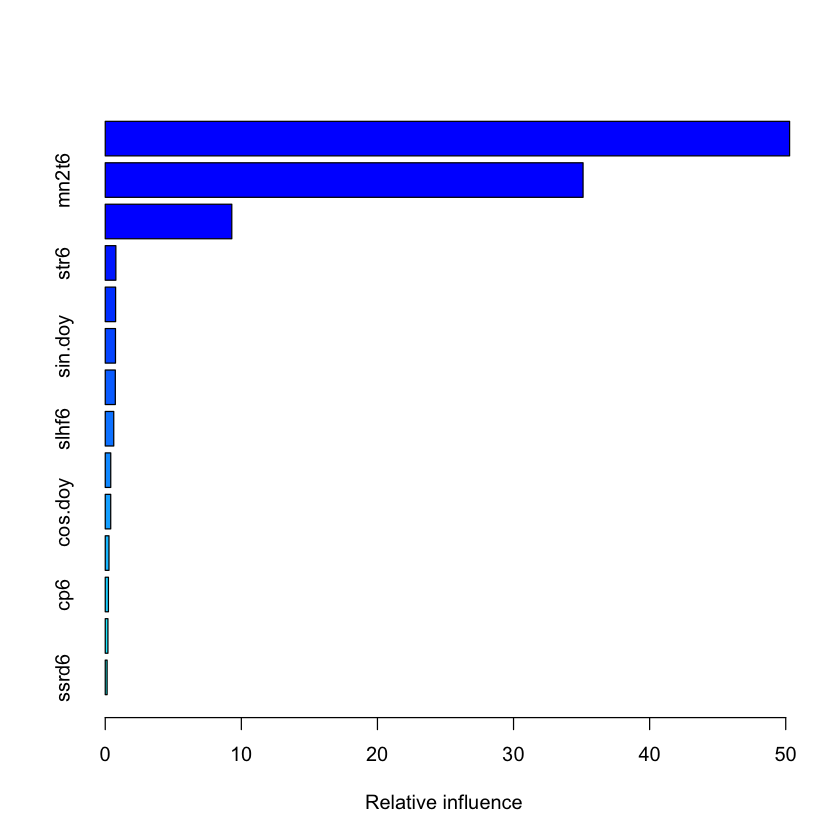

```
[1] "Relative Performance (GBM Model) for Station 704 : -0.0433529219893058"
[1] "MSE (GBM Model) for Station 704 : 6.26449482458848"
[1] "MSE (DMO) for Station 704 : 6.00419540939637"
Forecast at Station: 953 (5 from 49)
Elapsed time for grid search: 2.5464
Best parameters found:
$n.trees
[1] 300

$interaction.depth
[1] 5

$shrinkage
[1] 0.1

$bag.fraction
[1] 0.7

$n.minobsinnode
[1] 10

Best cross-validation error: 6.206421
[1] "mx2t6" "mn2t6" "dmo"   "slhf6" "str6"
```

```
Using 300 trees...
```

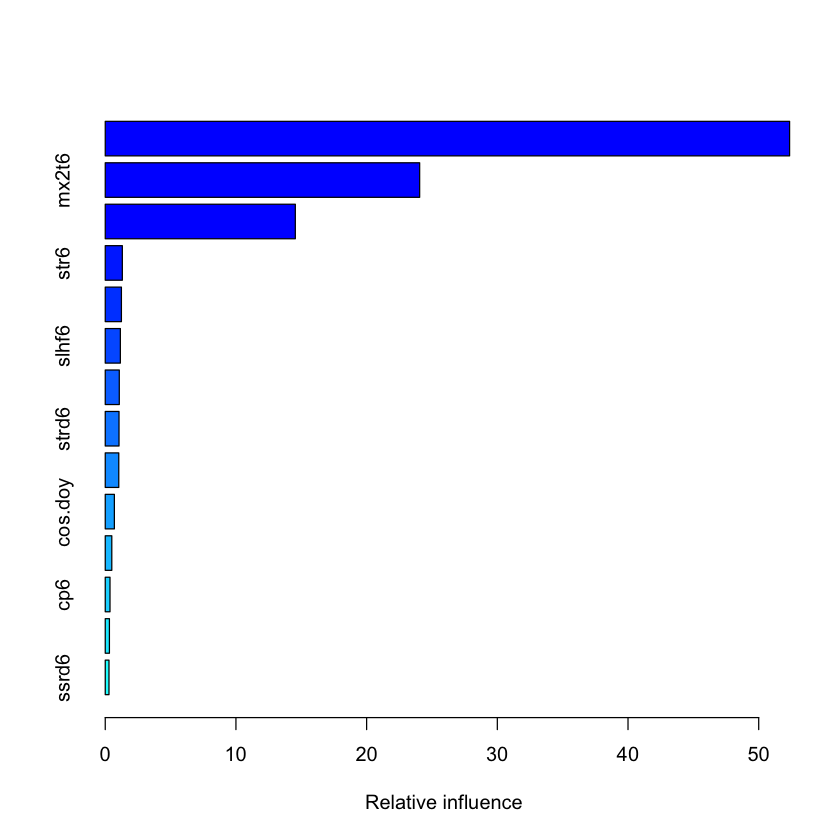

```
[1] "Relative Performance (GBM Model) for Station 953 : 0.243686333294131"
[1] "MSE (GBM Model) for Station 953 : 5.18969052778329"
[1] "MSE (DMO) for Station 953 : 6.86182301899559"
Forecast at Station: 963 (6 from 49)
Elapsed time for grid search: 2.542473
Best parameters found:
$n.trees
[1] 300

$interaction.depth
[1] 4

$shrinkage
[1] 0.1

$bag.fraction
[1] 0.7

$n.minobsinnode
[1] 5

Best cross-validation error: 6.567019
[1] "mn2t6"   "mx2t6"   "dmo"     "str6"    "cos.doy"
```

```
Using 300 trees...
```

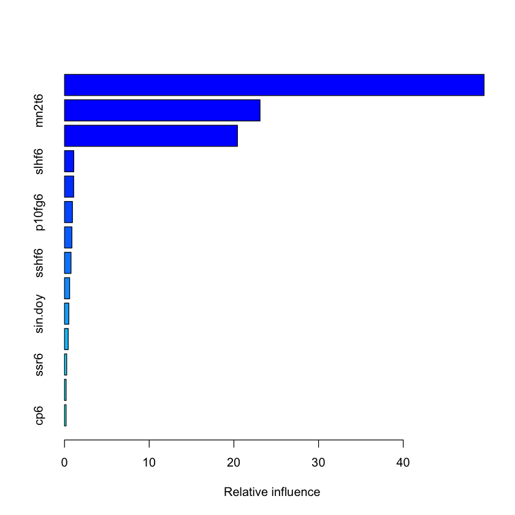

```
[1] "Relative Performance (GBM Model) for Station 963 : 0.109955218472003"
[1] "MSE (GBM Model) for Station 963 : 5.03826612668597"
[1] "MSE (DMO) for Station 963 : 5.66068835102483"
Forecast at Station: 1078 (7 from 49)
Elapsed time for grid search: 2.55463
Best parameters found:
$n.trees
[1] 300

$interaction.depth
[1] 4

$shrinkage
[1] 0.1

$bag.fraction
[1] 0.7

$n.minobsinnode
[1] 10

Best cross-validation error: 6.734917
[1] "mn2t6" "mx2t6" "dmo"   "str6"  "strd6"
```

```
Using 300 trees...
```

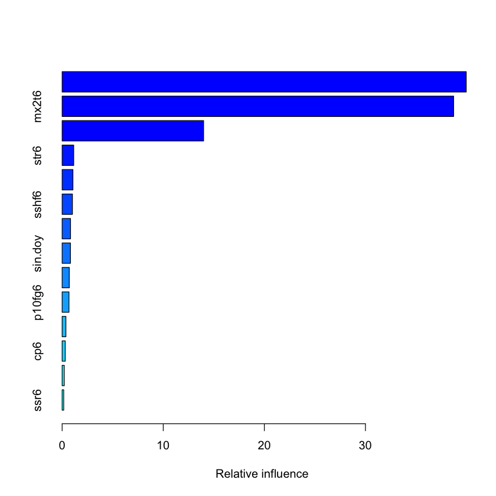

```
[1] "Relative Performance (GBM Model) for Station 1078 : 0.090117367001873"
[1] "MSE (GBM Model) for Station 1078 : 6.02116617849572"
[1] "MSE (DMO) for Station 1078 : 6.61751962300408"
Forecast at Station: 1303 (8 from 49)
Elapsed time for grid search: 2.540547
Best parameters found:
$n.trees
[1] 300

$interaction.depth
[1] 3

$shrinkage
[1] 0.1

$bag.fraction
[1] 0.7

$n.minobsinnode
[1] 10

Best cross-validation error: 5.310218
[1] "mx2t6"  "mn2t6"  "dmo"    "str6"   "p10fg6"
```

```
Using 300 trees...
```

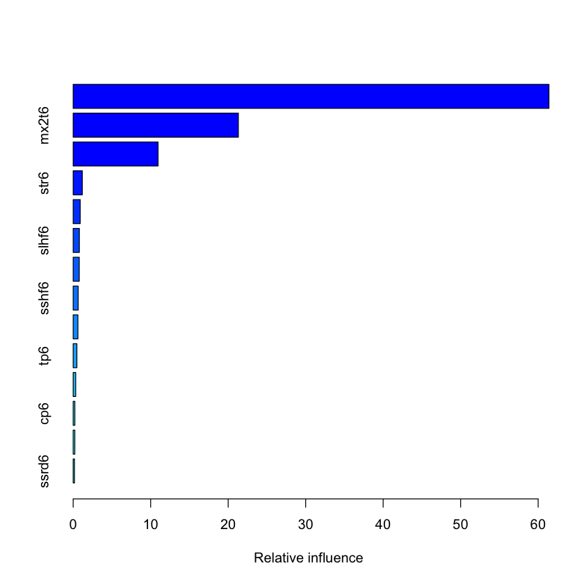

```
[1] "Relative Performance (GBM Model) for Station 1303 : 0.332082718962957"
[1] "MSE (GBM Model) for Station 1303 : 4.29141906445118"
[1] "MSE (DMO) for Station 1303 : 6.42507565875238"
Forecast at Station: 1346 (9 from 49)
Elapsed time for grid search: 2.551401
Best parameters found:
$n.trees
[1] 300

$interaction.depth
[1] 5

$shrinkage
[1] 0.1

$bag.fraction
[1] 0.7

$n.minobsinnode
[1] 5

Best cross-validation error: 8.467469
[1] "dmo"    "mx2t6"  "mn2t6"  "tp6"    "p10fg6"
```

```
Using 300 trees...
```

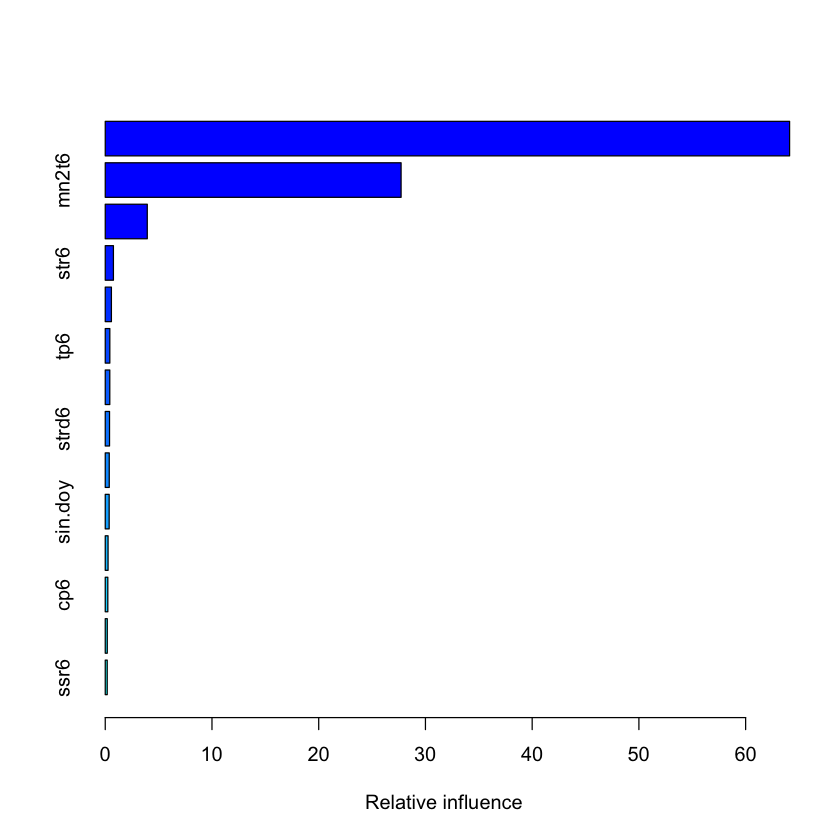

```
[1] "Relative Performance (GBM Model) for Station 1346 : 0.541779266935579"
[1] "MSE (GBM Model) for Station 1346 : 6.8466749262168"
[1] "MSE (DMO) for Station 1346 : 14.9418706579002"
Forecast at Station: 1420 (10 from 49)
Elapsed time for grid search: 2.53986
Best parameters found:
$n.trees
[1] 300

$interaction.depth
[1] 5

$shrinkage
[1] 0.1

$bag.fraction
[1] 0.7

$n.minobsinnode
[1] 10

Best cross-validation error: 6.600615
[1] "mx2t6" "mn2t6" "dmo"   "slhf6" "sshf6"
```

```
Using 300 trees...
```

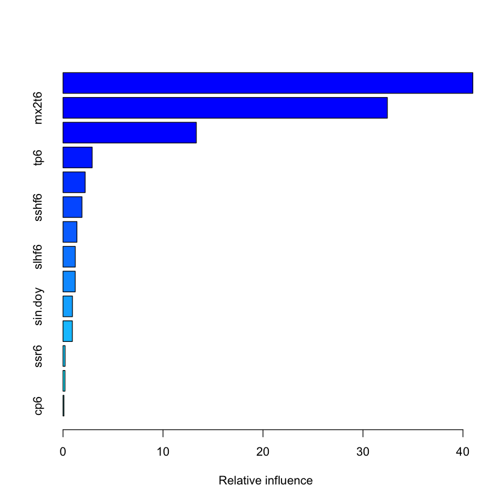

```
[1] "Relative Performance (GBM Model) for Station 1420 : 0.206462241243033"
[1] "MSE (GBM Model) for Station 1420 : 5.55355588932553"
[1] "MSE (DMO) for Station 1420 : 6.99847717142643"
Forecast at Station: 1443 (11 from 49)
Elapsed time for grid search: 2.542236
Best parameters found:
$n.trees
[1] 300

$interaction.depth
[1] 5

$shrinkage
[1] 0.1

$bag.fraction
[1] 0.7

$n.minobsinnode
[1] 5

Best cross-validation error: 8.514751
[1] "mx2t6" "mn2t6" "dmo"   "strd6" "sshf6"
```

```
Using 300 trees...
```

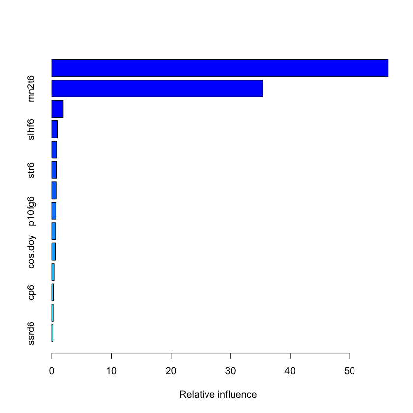

```
[1] "Relative Performance (GBM Model) for Station 1443 : -0.042589349182498"
[1] "MSE (GBM Model) for Station 1443 : 10.9016799211488"
[1] "MSE (DMO) for Station 1443 : 10.4563507479689"
Forecast at Station: 1468 (12 from 49)
Elapsed time for grid search: 2.542023
Best parameters found:
$n.trees
[1] 300

$interaction.depth
[1] 5

$shrinkage
[1] 0.1

$bag.fraction
[1] 0.7

$n.minobsinnode
[1] 5

Best cross-validation error: 5.846777
[1] "mx2t6" "dmo"   "mn2t6" "slhf6" "str6"
```

```
Using 300 trees...
```

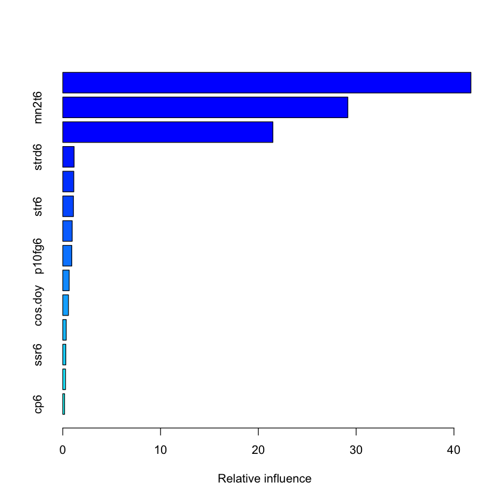

```
[1] "Relative Performance (GBM Model) for Station 1468 : 0.147949523412145"
[1] "MSE (GBM Model) for Station 1468 : 4.86737705897694"
[1] "MSE (DMO) for Station 1468 : 5.71254543330458"
Forecast at Station: 1580 (13 from 49)
Elapsed time for grid search: 2.531681
Best parameters found:
$n.trees
[1] 300

$interaction.depth
[1] 3

$shrinkage
[1] 0.1

$bag.fraction
[1] 0.7

$n.minobsinnode
[1] 10

Best cross-validation error: 5.712128
[1] "mx2t6"   "mn2t6"   "dmo"     "cos.doy" "str6"
```

```
Using 300 trees...
```

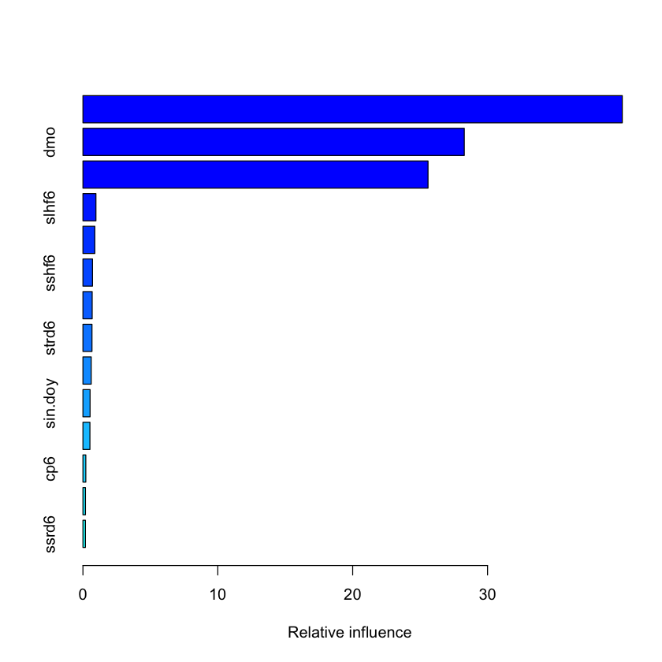

```
[1] "Relative Performance (GBM Model) for Station 1580 : 0.4539396945052"
[1] "MSE (GBM Model) for Station 1580 : 4.31089937415275"
[1] "MSE (DMO) for Station 1580 : 7.89454814930473"
Forecast at Station: 1639 (14 from 49)
Elapsed time for grid search: 2.535661
Best parameters found:
$n.trees
[1] 300

$interaction.depth
[1] 5

$shrinkage
[1] 0.1

$bag.fraction
[1] 0.7

$n.minobsinnode
[1] 5

Best cross-validation error: 6.222183
[1] "mx2t6" "mn2t6" "dmo"   "str6"  "slhf6"
```

```
Using 300 trees...
```

[39 more figures not shown]

```r
set.seed(123)

# Initialize a matrix to store predictions for all stations
num_stations <- length(unique(fcs.test$latlon$station.id))
my.pred_gbm <- matrix(data = NA, nrow = 730, ncol = num_stations)
top_features_list <- list()

observed_values <- numeric(0)
predicted_values <- numeric(0)
mse_gbm_values <- numeric(num_stations)
mse_dmo_values <- numeric(num_stations)
relative_performance_values <- numeric(num_stations)

# Define the constant lead time
this_leadtime <- 120

# Define station IDs (you can modify this list accordingly)
station_ids <- unique(fcs.test$latlon$station.id)

# Loop over stations
for (st in station_ids) {
  cat(paste0('Forecast at Station: ', st, ' (', which(fcs.test$latlon$station.id == st), ' from ', num_stations, ')\n'))

  # Prepare test data for this station and lead time
  idx.lt <- which(obs.test$leadtime == this_leadtime)
  idx.sta <- which(obs.test$latlon$station.id == st)
  obs <- obs.test$data$t2m[idx.lt,,idx.sta]
  time <- obs.test$time + this_leadtime * 3600
  obs <- cbind(obs.test$time, this_leadtime, st, obs)
  obs <- zoo(obs, time)
  colnames(obs) <- c('init', 'lt', 'stat', 'obs')

  idx.lt <- which(fcs.test$leadtime == this_leadtime)
  dmo <- fcs.test$data$t2m[idx.lt,,idx.sta]
  tp6 <- fcs.test$data$tp6[idx.lt,,idx.sta]
  sshf6 <- fcs.test$data$sshf6[idx.lt,,idx.sta]
  slhf6 <- fcs.test$data$slhf6[idx.lt,,idx.sta]
  ssr6 <- fcs.test$data$ssr6[idx.lt,,idx.sta]
  str6 <- fcs.test$data$str6[idx.lt,,idx.sta]
  cp6 <- fcs.test$data$cp6[idx.lt,,idx.sta]
  mx2t6 <- fcs.test$data$mx2t6[idx.lt,,idx.sta]
  mn2t6 <- fcs.test$data$mn2t6[idx.lt,,idx.sta]
  ssrd6 <- fcs.test$data$ssrd6[idx.lt,,idx.sta]
  strd6 <- fcs.test$data$strd6[idx.lt,,idx.sta]
  p10fg6 <- fcs.test$data$p10fg6[idx.lt,,idx.sta]

  # Combine all parameters into the test data frame
  test <- cbind(dmo, tp6, sshf6, slhf6, ssr6, str6, cp6, mx2t6, mn2t6, ssrd6, strd6, p10fg6)
  time <- fcs.test$time + this_leadtime * 3600
  test <- zoo(test, time)
  test <- merge(obs, test)

  # Prepare training data
  trai.all <- NULL
  for (year in fcs.train$year) {
    idx.lt <- which(obs.train$leadtime == this_leadtime)
    idx.year <- which(obs.train$year == year)
    idx.sta <- which(obs.train$latlon$station.id == st)
    obs <- obs.train$data$t2m[idx.lt, idx.year, , idx.sta]
    year.dummy <- as.POSIXct(paste0(2017 - 20 + year, '-01-02'))
    time <- year.dummy + obs.train$time * 3600 * 24 + this_leadtime * 3600
    fctime_obs_trai <- year.dummy + obs.train$time * 3600 * 24
    obs <- cbind(fctime_obs_trai, this_leadtime, st, obs)
    obs <- zoo(obs, time)
    colnames(obs) <- c('init', 'lt', 'stat', 'obs')

    dmo <- fcs.train$data$t2m[idx.lt, idx.year, , idx.sta]
    tp6 <- fcs.train$data$tp6[idx.lt, idx.year, , idx.sta]
    sshf6 <- fcs.train$data$sshf6[idx.lt, idx.year, , idx.sta]
    slhf6 <- fcs.train$data$slhf6[idx.lt, idx.year, , idx.sta]
    ssr6 <- fcs.train$data$ssr6[idx.lt, idx.year, , idx.sta]
    str6 <- fcs.train$data$str6[idx.lt, idx.year, , idx.sta]
    cp6 <- fcs.train$data$cp6[idx.lt, idx.year, , idx.sta]
    mx2t6 <- fcs.train$data$mx2t6[idx.lt, idx.year, , idx.sta]
    mn2t6 <- fcs.train$data$mn2t6[idx.lt, idx.year, , idx.sta]
    ssrd6 <- fcs.train$data$ssrd6[idx.lt, idx.year, , idx.sta]
    strd6 <- fcs.train$data$strd6[idx.lt, idx.year, , idx.sta]
    p10fg6 <- fcs.train$data$p10fg6[idx.lt, idx.year, , idx.sta]

    trai <- cbind(dmo, tp6, sshf6, slhf6, ssr6, str6, cp6, mx2t6, mn2t6, ssrd6, strd6, p10fg6)
    time <- year.dummy + fcs.train$time * 3600 * 24 + this_leadtime * 3600
    trai <- zoo(trai, time)
    trai <- merge(obs, trai)
    trai.all <- rbind(trai.all, trai)
  }

  trai <- na.omit(trai.all)
  trai <- trai[which(index(trai) < as.POSIXct('2017-01-01')),]

  # Convert K to °C (run only once!)
  trai$obs <- trai$obs - 273.15
  test$obs <- test$obs - 273.15
  trai$dmo <- trai$dmo - 273.15
  test$dmo <- test$dmo - 273.15
  trai$mx2t6 <- trai$mx2t6 - 273.15
  test$mx2t6 <- test$mx2t6 - 273.15
  trai$mn2t6 <- trai$mn2t6 - 273.15
  test$mn2t6 <- test$mn2t6 - 273.15

  # Adding sine and cosine for day of the year to capture seasonality
  yday <- as.POSIXlt(index(trai))$yday
  trai$sin.doy <- sin(2 * pi * yday / 365)
  trai$cos.doy <- cos(2 * pi * yday / 365)

  yday <- as.POSIXlt(index(test))$yday
  test$sin.doy <- sin(2 * pi * yday / 365)
  test$cos.doy <- cos(2 * pi * yday / 365)

  # Assuming 'obs' is your target variable in `trai`
  target <- trai$obs

  # Assuming 'obs' is your target variable in `trai`
  target <- trai$obs

  # Select features from `trai`
  features <- trai[, c("dmo", "sin.doy", "cos.doy", "strd6", "mx2t6", "mn2t6", "tp6",
                       "sshf6", "slhf6", "ssr6", "str6", "cp6", "p10fg6", "ssrd6")]

  # Define the parameter grid for hyperparameter tuning
  param_grid <- list(
    n.trees = c(100, 200, 300),
    interaction.depth = c(3, 4, 5),
    shrinkage = c(0.1, 0.01),
    n.minobsinnode = c(5, 10)     # Adjust based on your preference
  )

  # Initialize variables to store the best parameters and error
  best_params <- NULL
  best_error <- Inf

  # Measure the start time of grid search
  start_time <- Sys.time()

  # Perform grid search for hyperparameter tuning
  for (n_trees in param_grid$n.trees) {
    for (depth in param_grid$interaction.depth) {
      for (shrink in param_grid$shrinkage) {
        for (min_obs in param_grid$n.minobsinnode) {

          # Train a GBM model with cross-validation
          gbm_model <- gbm(
            formula = target ~ .,
            data = features,
            distribution = "gaussian",
            n.trees = n_trees,
            interaction.depth = depth,
            shrinkage = shrink,
            bag.fraction = 0.7,     # Learning rate (shrinkage)
            n.minobsinnode = min_obs,
            cv.folds = 5,           # Number of folds for cross-validation
            verbose = FALSE        # Suppress verbose output
          )

          # Calculate cross-validation error manually
          cv_error <- mean(gbm_model$cv.error)

          # Update best parameters if this model is better
          if (cv_error < best_error) {
            best_error <- cv_error
            best_params <- list(
              n.trees = n_trees,
              interaction.depth = depth,
              shrinkage = shrink,
              bag.fraction = 0.7,
              n.minobsinnode = min_obs
            )

            # Store the best model for feature importance extraction
            best_gbm_model <- gbm_model
          }
        }
      }
    }
  }

  # Measure the end time of grid search
  end_time <- Sys.time()

  # Print the elapsed time for grid search
  cat("Elapsed time for grid search:", end_time - start_time, "\n")

  # Print the best parameters and error found
  cat("Best parameters found:", "\n")
  print(best_params)
  cat("Best cross-validation error:", best_error, "\n")

  # Extract variable importance from the best model
  importance_df <- summary(best_gbm_model)

  # Sort features by relative importance
  sorted_indices <- order(-importance_df$rel.inf)
  top_features <- importance_df$var[sorted_indices[1:5]]

  top_features_list[[as.character(st)]] <- top_features


  print(top_features)

  # Train the final GBM model with selected features
  final_gbm_model <- gbm(
    formula = target ~ .,
    data = features[, top_features],
    distribution = "gaussian",
    n.trees = best_params$n.trees,
    interaction.depth = best_params$interaction.depth,
    shrinkage = best_params$shrinkage,
    bag.fraction = best_params$bag.fraction,
    n.minobsinnode = best_params$n.minobsinnode,
    verbose = FALSE        # Suppress verbose output
  )

  # Make predictions on test set
  predictions <- predict(final_gbm_model, newdata = test)

  # Store predictions for this station
  my.pred_gbm[, which(station_ids == st)] <- predictions

  # Evaluate performance
  mse_gbm <- mean((test$obs - predictions)^2, na.rm = TRUE)
  mse_dmo <- mean((test$obs - test$dmo)^2, na.rm = TRUE)
  relative_performance_gbm <- 1 - mse_gbm / mse_dmo
  print(paste("Relative Performance (GBM Model) for Station", st, ":", relative_performance_gbm))
  print(paste("MSE (GBM Model) for Station", st, ":", mse_gbm))
  print(paste("MSE (DMO) for Station", st, ":", mse_dmo))

  # Store MSE and relative performance
  station_index <- which(station_ids == st)

  mse_gbm_values[station_index] <- mse_gbm
  mse_dmo_values[station_index] <- mse_dmo
  relative_performance_values[station_index] <- relative_performance_gbm

  observed_values <- c(observed_values, test$obs)
  predicted_values <- c(predicted_values, predictions)


}

# Save predictions matrix in RDS format
saveRDS(my.pred_gbm, file = "my.GBM.MOS_group_X3.rds")
saveRDS(top_features_list, file = "top_features_list.rds")


na_indices <- which(!is.na(observed_values) & !is.na(predicted_values))
observed_values <- observed_values[na_indices]
predicted_values <- predicted_values[na_indices]


overall_r_squared <- cor(observed_values, predicted_values)^2
overall_rmse <- sqrt(mean((observed_values - predicted_values)^2))
overall_mse <- mean((observed_values - predicted_values)^2)

# Print overall metrics
print(paste("Overall R-squared:", overall_r_squared))
print(paste("Overall RMSE:", overall_rmse))
print(paste("Overall MSE:", overall_mse))

# Create a data frame for plotting
plot_data <- data.frame(
  StationID = as.factor(station_ids),
  MSE_GBM = mse_gbm_values,
  MSE_DMO = mse_dmo_values,
  RelativePerformance = relative_performance_values
)

# Line plot for MSE comparison
mse_plot <- ggplot(plot_data, aes(x = StationID)) +
  geom_line(aes(y = MSE_GBM, color = "GBM", group = 1), size = 1) +
  geom_line(aes(y = MSE_DMO, color = "DMO", group = 1), size = 1) +
  labs(title = "MSE for GBM and DMO Models by Station", y = "MSE", x = "Station ID") +
  scale_color_manual(name = "Model", values = c("GBM" = "blue", "DMO" = "red")) +
  theme_minimal() +
  theme(axis.text.x = element_text(angle = 90, hjust = 1))

# Print the MSE plot
print(mse_plot)

# Relative performance plot
relative_performance_plot <- ggplot(plot_data, aes(x = StationID, y = RelativePerformance)) +
  geom_bar(stat = "identity", fill = "green") +
  labs(title = "Relative Performance of GBM Model by Station", y = "Relative Performance", x = "Station ID") +
  theme(axis.text.x = element_text(angle = 90, hjust = 1))

# Print the relative performance plot
print(relative_performance_plot)
```